# Classification and Clustering of phones by physical sensor data

*by Benoît Boucher, 2018-07-27*

## Context

This is my complete and commented solution to the Capstone Project I proposed to Udacity required in order to graduate from the *Machine Learning Engineer Nanodegree*.

While I will provide some background information here, the focus of this notebook is really on solving the project and to expose the code required to repeat my solution. You can find more details surrounding the project itself by reading the [proposal](https://github.com/Fluzzroz/Contxtful-phone-model/blob/master/Benoit-Boucher-Capstone-Proposal.md) or the [final report](https://github.com/Fluzzroz/Contxtful-phone-model/blob/master/Benoit-Boucher-Capstone-Report.pdf)

My project was done in collaboration with CONTXTFUL, who supplied my data set.

CONTXTFUL is a web marketing company that specializes in using smartphone physical sensor data, such as the gyroscope and acceleration sensors, to detect the context of users. For instance, are they at rest or walking? Are they looking at their screen or not?

## Problem statement

The primary goal is to identify smartphones' make-model based solely on their physical data. This can be measured by the F1 score.

As a secondary target, it would be interesting to cluster the phones and see if a natural separation of the samples occur based on their make-models. This can be measured by weighting the representation of each phone make-models into the clusters.

### phone <=> make-model

For simplicity, I will henceforth use the term *phone* as shorthand for *smartphone's make-model*. This will also make it clearer that when I use the word *model*, I am referring to a Machine Learning (ML) algorithm or an instance thereof.

## Data set

The dataset is derived from a measure of a phone's physical sensors. What CONTXTFUL calls a *raw_data_vector* is generated every second and includes all data points from the various sensors (X-Y-Z gyroscope, X-Y-Z accelerometer, etc) sampled at the phone's sample rate. This rate varies by model, but is generally in the range of 16-32 Hz. Moreover, not all phones are equipped with the same sensors. For instance, some phones do not have a gyroscope. Consequently, *raw_data_vectors* do not have a consistent length. This means that they cannot be used as input for a ML model.

Being proprietary, the *raw_data_vector* will not be available to the public in this project.

What will be available for my ML models is what CONTXTFUL refers to as *full_stat_vector*, which is a features vector engineered from the *raw_data_vector*. The *full_stat_vector* is a vector of consistent length containing a slew of various statistical metrics. For instance: maximum_gyroscope_speed_Z, first_derivate_linear_acceleration_Y, mean_euclidean_speed, etc.

Note that for confidentiality reasons, I have anonymized the dataset.

```python
import pandas as pd
import matplotlib.pyplot as plt
import numpy as np
import Utilities, itertools
from scipy.stats import randint, uniform
from sklearn.externals import joblib
from sklearn.model_selection import train_test_split, RandomizedSearchCV, ShuffleSplit
from sklearn.preprocessing import normalize
from sklearn.discriminant_analysis import LinearDiscriminantAnalysis as LDA
from sklearn.metrics import f1_score
from sklearn.mixture import GaussianMixture
from sklearn.cluster import MeanShift, DBSCAN, KMeans, AgglomerativeClustering
from sklearn.ensemble import RandomForestClassifier
from sklearn.linear_model import SGDClassifier
from keras import Sequential
from keras.layers import Dense, Dropout, Activation, ActivityRegularization
from keras.callbacks import ModelCheckpoint
from keras.utils import to_categorical
from keras.models import load_model
```

```python
#import data
dataset = pd.read_pickle("dataset.xz")
X = dataset.iloc[:,1:].values
y = dataset.model.values


#pre-processing
X_norm = normalize(X)
X_train, X_test, X_train_norm, X_test_norm, y_train, y_test = train_test_split(X, X_norm, y, random_state=42)

#utilities for visualizations
figsize = (10,9)
i_labels, phone_counts = np.unique(y, return_counts=True)
phone_labels = []
colors = []
for i in i_labels:
    phone_labels.append("Phone_{}".format(i))
    colors.append(plt.cm.tab20(i))
```

```python
print("Shape of our input features:", X.shape)
print("Shape of our target labels", y.shape)
print("Type of data:", type(X[0,0]))
```

```
Shape of our input features: (12110, 1652)
Shape of our target labels (12110,)
Type of data: <class 'numpy.float64'>
```

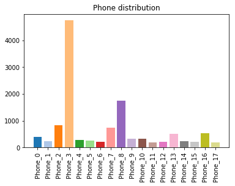

```python
#phone distribution
title = "Phone distribution"
plt.bar(x=i_labels, height=phone_counts, color=colors)
plt.title(title)
plt.xticks(i_labels, phone_labels, rotation="vertical")
plt.show()
#plt.savefig("images/Phone_Distribution.png", bbox_inches="tight")
```

As we can see in the graph above, the target labels are not uniform. This is a consequence of using real-life data. This is why I will use the F1 score as a metric for my classification models.

## Benchmark

I will compare my models against what CONTXTFUL achieved. First, let me replicate it here.

```python
#model initialization and training
clf = LDA(n_components=2)
clf.fit(X_train,y_train)
```

```
LinearDiscriminantAnalysis(n_components=2, priors=None, shrinkage=None,
              solver='svd', store_covariance=False, tol=0.0001)
```

```python
print(clf.explained_variance_ratio_)
```

```
[ 0.8088817   0.05208979]
```

```python
#score
y_predict = clf.predict(X_test)
score = f1_score(y_test, y_predict, average="weighted")
print("LDA F1 score: {:.2%}".format(score))
```

```
LDA F1 score: 78.33%
```

This is a respectable prediction score. **Classification benchmark: 78.33%**

### CONTXTFUL... Towards Clustering

Below is a histogram of the samples values along the first principal component of the LDA model.

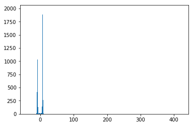

```python
X_prime = clf.transform(X)
plt.hist(X_prime[:,0], bins=1000)
plt.show()
#plt.savefig("images/LDA_histo_full_view.png", bbox_inches="tight")
```

Not much can be seen, but let's zoom in the middle. Effectively, it's the same as cutting the outliers.

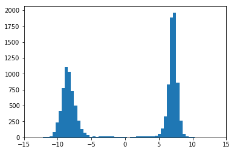

```python
plt.hist(X_prime[:,0], bins=1000)
plt.xlim(-15, 15)
plt.show()
#plt.savefig("images/LDA_histo_zoomed_view.png", bbox_inches="tight")
```

There are clearly 2 peaks, and a case could be made for more.

Since LDA is a form of supervised clustering, this graph really piqued CONTXTFUL's curiosity. What would happen if the phones' *full_stat_vector* were clustered in an unsupervised way? Would their make-model group up naturally into neat clusters?

We can get a clue by plotting a 2D scatter plot of our true labels on the 2 principal axes we obtained from LDA.

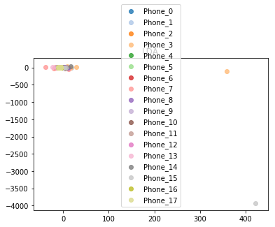

```python
for category, label in enumerate(phone_labels):
    plt.scatter(X_prime[y == category,0], X_prime[y == category,1],
                alpha=.8,color=colors[category], label=label)
plt.legend(loc='best', shadow=False, scatterpoints=1)
plt.title('LDA')
plt.show()
#plt.savefig("images/LDA_scatter_full_view.png", bbox_inches="tight")
```

We should have expected this... Did you? Let's zoom in.

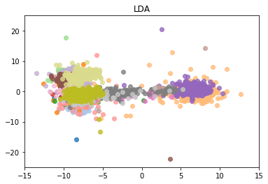

```python
for category, label in enumerate(phone_labels):
    plt.scatter(X_prime[y == category,0], X_prime[y == category,1],
                alpha=.8,color=colors[category], label=label)

plt.title('LDA')
plt.xlim(-15,15)
plt.ylim(-25,25)
plt.show()
#plt.savefig("images/LDA_scatter_zoomed_view.png", bbox_inches="tight")
```

Those look like clusters to me! But remember, they were derived from a *supervised* clustering technique.

What about *unsupervised?* Let's find out next.

## CONTXTFUL Clustering: GMM (Gaussian Mixture Model)

First we will search for the optimal number of clusters. This can be indicated by the [Bayesian Information Criteria (BIC)](https://en.wikipedia.org/wiki/Bayesian_information_criterion).

```python
lowest_bic = np.infty
bic = []
n_components = [4,5,6,8,9,10,13,14,15,17,18,19]
cv_types = ['spherical', 'tied', 'diag', 'full']
for cv_type in cv_types:
    for n_component in n_components:
        # Fit a Gaussian mixture with EM
        gmm = GaussianMixture(n_components=n_component, covariance_type=cv_type, reg_covar=1e-2)
        gmm.fit(X)
        bic.append(gmm.bic(X))
```

```python
#Because this calculation takes more than an hour, I'll save the results so the next guy can skip it.
#joblib.dump(bic, "saved_models/bic.pkl")
#bic = joblib.load("saved_models/bic.pkl")
```

[output not shown]

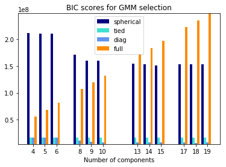

```python
#Plot the BIC scores
bic = np.array(bic)
color_iter = itertools.cycle(['navy', 'turquoise', 'cornflowerblue', 'darkorange'])
bars = []

for i, (cv_type, color) in enumerate(zip(cv_types, color_iter)):
    xpos = np.array(n_components) + .2 * (i - 2)
    bars.append(plt.bar(xpos, bic[i * len(n_components):(i + 1) * len(n_components)],
        width=.2, color=color))

plt.xticks(n_components)
plt.ylim([bic.min() * 1.01 - .01 * bic.max(), bic.max()])
plt.xlabel('Number of components')
plt.legend([b[0] for b in bars], cv_types)
plt.title('BIC scores for GMM selection')
plt.show()
#plt.savefig("images/BIC_scores_full_view.png", bbox_inches="tight")
```

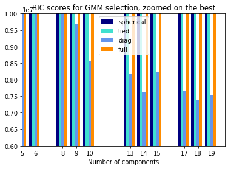

```python
#Plot the BIC scores again, zooming on the lowest BICs
bic = np.array(bic)
color_iter = itertools.cycle(['navy', 'turquoise', 'cornflowerblue', 'darkorange'])
bars = []

for i, (cv_type, color) in enumerate(zip(cv_types, color_iter)):
    xpos = np.array(n_components) + .2 * (i - 2)
    bars.append(plt.bar(xpos, bic[i * len(n_components):(i + 1) * len(n_components)],
        width=.2, color=color))

plt.xticks(n_components)
plt.ylim(6000000,10000000)
plt.xlim(5,20)
plt.xlabel('Number of components')
plt.legend([b[0] for b in bars], cv_types)
plt.title('BIC scores for GMM selection, zoomed on the best')
plt.show()
#plt.savefig("images/BIC_scores_zoomed_view.png", bbox_inches="tight")
```

The BIC have determined quite convincingly that "diag" is the best cv_type. As for n_components, a few are pretty good. The absolute best is 18, which is nice because there are 18 target labels. So I will start with that, but I have a feeling we we will want to look at more options...

```
Saved: images/gmm_18_clusters.png
Saved: images/gmm_8_clusters.png
Saved: images/gmm_4_clusters.png
Saved: images/gmm_2_clusters.png
```

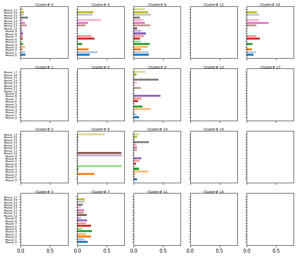

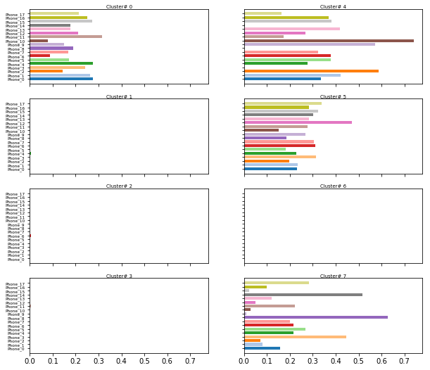

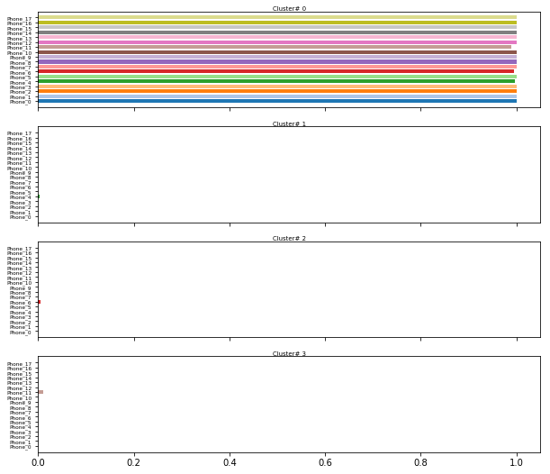

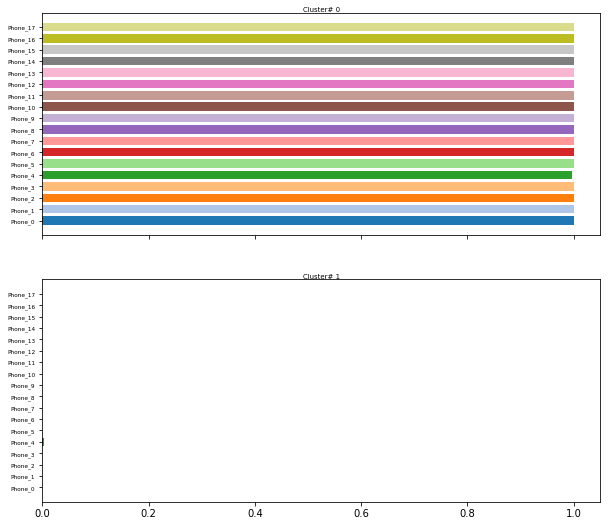

```python
n_clusters = [18, 8, 4, 2]
cluster_scores = []

for n_cluster in n_clusters:
    clf = GaussianMixture(n_components=n_cluster, covariance_type="diag", reg_covar=1e-4)
    clf.fit(X)
    y_predict = clf.predict(X)
    lcm = Utilities.LabelClusterMatrix(y, y_predict, phone_labels)

    #visualization and save fig
    filepath = "images/gmm_" + str(n_cluster) + "_clusters.png"
    Utilities.HistoCluster(lcm, filepath, figsize)

    #save score
    cluster_scores.append(Utilities.ClusterScore(lcm))
```

Each figure shows a number of subplots equal to the number of clusters selected.

Each subplot is a barplot with each bar representing one of the true label (ie: Phone_0 through Phone_17). Every label has its own color and it is consistent across all plots and subplots. The x axis represents the ratio of a particular phone inside that particular cluster.

After seeing that half of the clusters in n_clusters are empty, I decided to try and cut them out. If there were 8 true clusters before, maybe choosing n_clusters=8 will give me 8 trues clusters? The second figure shows the result of using n_clusters=8. Surprisingly, the same effect of having half the clusters empty (technically, they contain exactly 1 sample). As for label separation, it is even worse than n_clusters=18. Every phone is more or less uniformly present in every "true" cluster.

I repeated the experiment with 4 and 2 clusters. At those numbers, there is no clustering to speak of.

What about the clustering score?

```python
for n, s in zip(n_clusters, cluster_scores):
    print("# of clusters: {}\tScore: {:.2%}".format(n, s))
```

```
# of clusters: 18	Score: 89.84%
# of clusters: 8	Score: 76.51%
# of clusters: 4	Score: 99.89%
# of clusters: 2	Score: 99.96%
```

The metric I devised should be close to 1 when the labels are neatly seperated and close to 0 when they are uniformly distributed.

Unfortunately, the metric completely fails here: when no clustering takes place, everything is extremely well seperated. It's easy to see why n_clusters 2 and 4 are so high, but we cannot neglect the impact that having half of your clusters completely empty does to the scores of n_clusters 8 and 18. The impact is an unduly inflation of the score.

*Note: running the code again gives non-identical results. The general sense of the comments apply (dominent peaks, absent colors) but the details vary (which peak, which cluster)*

## Clustering

Now that we have benchmarks for our two goals (classification and clustering), let's try other some of our own models. I'll start with clustering.

### MeanShift

```
Saved: images/MeanShift.png
```

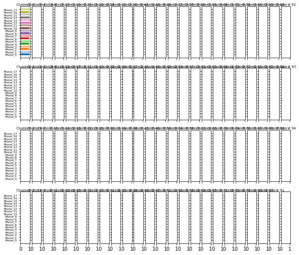

```python
clf = MeanShift(n_jobs=-1)
y_predict = clf.fit_predict(X)
lcm = Utilities.LabelClusterMatrix(y, y_predict, phone_labels)
Utilities.HistoCluster(lcm, "images/MeanShift.png", figsize)
```

```python
print("Clustering Score:", Utilities.ClusterScore(lcm))
```

```
Clustering Score: 0.9993803044445585
```

This clustering algorithm does not scale well with large datasets. It took 4 hours to run. After waiting this long, the results are underwhelming since not much clustering took place: only the first cluster contains almost all the samples while there remaining 94 clustesr have between 1 and 3 samples each. This is the weakness of my metric, thus its very high Clustering Score.

### DBSCAN

I tried the DBSCAN clusterer with a couple of different algorithms (auto, ball_tree). To converge at all, you need to normalize the data. Even then, it creates 31 categories, puts 1/3 of data into "unclassified", 2/3 into Category 0, and the rest is dispersed into the remaining categories in groups of 10-30. Again, the Clustering Score is very high, but that's because of its weakness against non-clusters.

Below are the results.

```
Saved: images/DBSCAN.png
DBSCAN Clustering Score: 0.9641880188733408
```

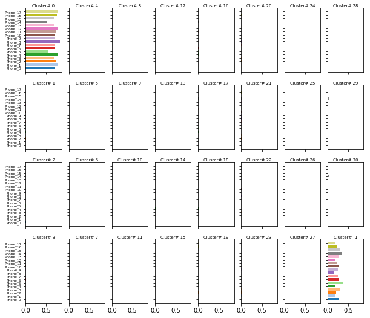

```python
clf = DBSCAN(n_jobs=-1)
y_predict = clf.fit_predict(X_norm)
lcm = Utilities.LabelClusterMatrix(y, y_predict, phone_labels)
Utilities.HistoCluster(lcm, "images/DBSCAN.png", figsize)
print("DBSCAN Clustering Score:", Utilities.ClusterScore(lcm))
```

### Agglomerative

I never got it to cluster my data. Almost all of it is in the same cluster (12075 points) while the remaining 35 points are distributed in the other clusters (1-5 points each).

I tried with affinity=[l1, l2, euclidean], linkage=[average, complete, ward], and n_clusters=[4,5,18].

Normalizing does not help, neither does it make it worse. Then again, how could it?

```
Saved: images/Agglo.png
Agglomerative Clustering Score: 0.9989657459265124
```

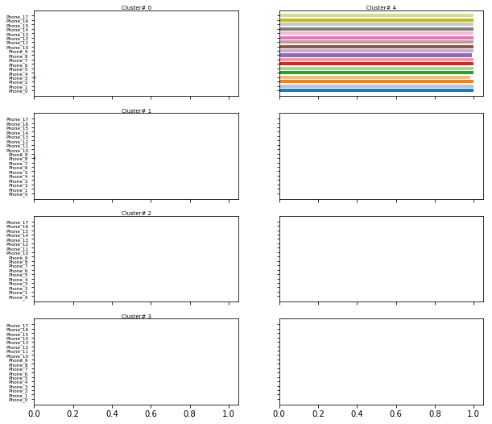

```python
#other hyperparameters were tried, these are the best ones
clf = AgglomerativeClustering(n_clusters=5, affinity="l1", linkage="average")
y_predict = clf.fit_predict(X_norm)
lcm = Utilities.LabelClusterMatrix(y, y_predict, phone_labels)
Utilities.HistoCluster(lcm, "images/Agglo.png", figsize)
print("Agglomerative Clustering Score:", Utilities.ClusterScore(lcm))
```

### KMeans

My personal best.

There are sparse clusters (yay!) and homogenous ones (boo!). Ideally, the sparse clusters would have had unique labels, but it did not happen. At least all the clusters are significant, as opposed to all other techniques tried, including the benchmark.

```
Saved: images/Kmeans.png
KMeans Clustering Score: 0.7599574744937254
```

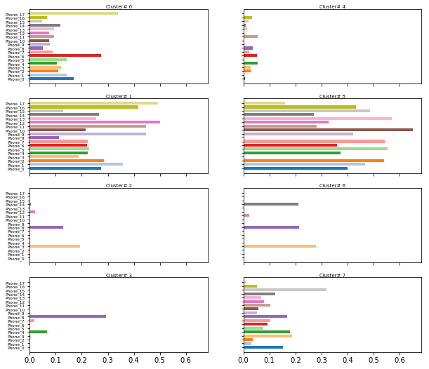

```python
clf = KMeans(n_clusters=8, n_jobs=-1)
y_predict = clf.fit_predict(X_norm)
lcm = Utilities.LabelClusterMatrix(y, y_predict, phone_labels)
Utilities.HistoCluster(lcm, "images/Kmeans.png", figsize)
print("KMeans Clustering Score:", Utilities.ClusterScore(lcm))
```

So **my best clustering score is the Kmeans with 76.00%** (all the other ones are eliminated by default because no clustering took place).

While this number is slightly lower than our benchmark (76.51%), I consider it better since half of the benchmark's clusters were empty, which inflated its score.

In any case, there are 2 lessons here:

1. The metric needs to be improved to take into account the empty clusters.
2. Phones do not cluster naturally into their make-model when using physical sensor data as input.

This concludes are attemps at clustering. Let's move on to Classification.

## Classification

First, notice that in all the following models, we will now use a train_test split of our data. This is because unlike clustering, we are actively trying to predict labels and the split allows us to avoid overfitting.

### Stochastic Gradient Descent (SGD)

The first classification I have tried was a simple SGD.

However, there are many different loss-functions that can be used, so the model can vary widely. In order to help decide which is best, I tried all of them and plotted their learning curves.

Also, as noted in [scikit-learn's description](http://scikit-learn.org/stable/modules/generated/sklearn.linear_model.SGDClassifier.html#sklearn.linear_model.SGDClassifier), it is better to have data with 0 mean and unit variance, so we will use normalized version of X.

Another note, the loss-function "hinge" turns SGD into a Support Vector Machine (SVM).

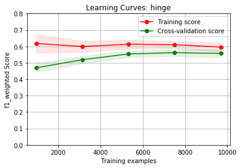

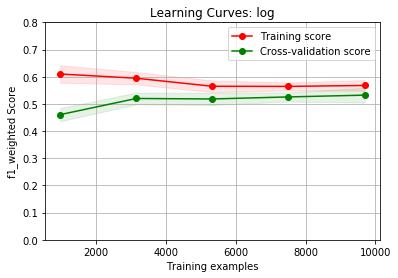

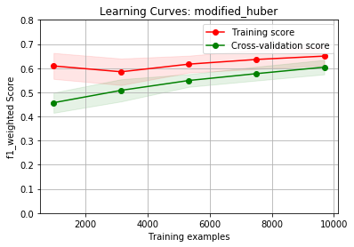

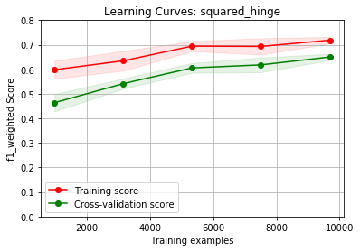

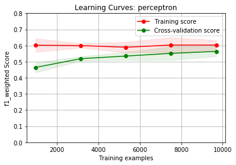

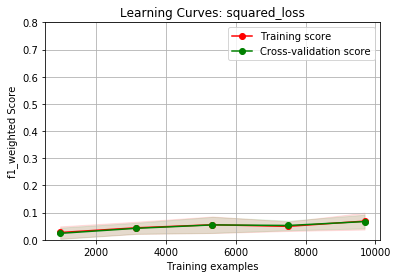

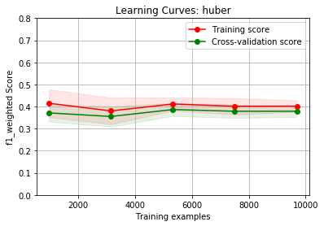

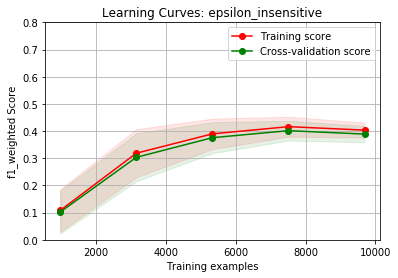

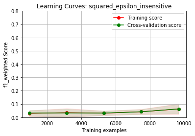

```python
c_v = ShuffleSplit(n_splits = 10, test_size=0.2, random_state = 42)

lossfuncs = ["hinge", "log", "modified_huber", "squared_hinge", "perceptron",
             "squared_loss", "huber", "epsilon_insensitive", "squared_epsilon_insensitive"]

for lossfunc in lossfuncs:
    title = "Learning Curves: " + lossfunc
    clf = SGDClassifier(loss=lossfunc)
    Utilities.plot_learning_curve(clf, title, X_norm, y, scoring="f1_weighted", ylim=(0.0, 0.8), cv=c_v, n_jobs=4)
```

The best is by far "squared_hinge", so that's the one we will be optimising.

We can see that using about 75% of the data as training leads to a good accuracy without overfitting. This corresponds to the default train_test_split, so no need to adjust it.

I have chosen Random Search over Grid Search because of [this article](https://analyticsindiamag.com/why-is-random-search-better-than-grid-search-for-machine-learning/).

Also, because I want to try different values of the "tol" parameter that vary by 2 orders of magnitude (from 0.0001 to 0.01), I have written my own random distribution, which is log-uniform. Otherwise, a simple uniform distribution would have favored larger values of tol.

```python
#train and score the base model
SGD = SGDClassifier(penalty="elasticnet", loss="squared_hinge")
SGD.fit(X_train_norm, y_train)
y_predict = SGD.predict(X_test_norm)
score = f1_score(y_test, y_predict, average="weighted")
print("Unoptimized SGD_squared_hinge F1 score: {:.2%}".format(score))
```

```
Unoptimized SGD_squared_hinge F1 score: 63.58%
```

```python
#optimize hyperparameters
param_dist = {"alpha": Utilities.log_uniform(-6,2),
              "l1_ratio": uniform(0,1),
              "tol": Utilities.log_uniform(-4, -2)
              }

clf = SGDClassifier(penalty="elasticnet", loss="squared_hinge")
random_search = RandomizedSearchCV(clf, param_dist, 20, n_jobs=4)
random_search.fit(X_norm, y)
joblib.dump(random_search, "saved_models/SGD_random_search.pkl")
```

```
['saved_models/SGD_random_search.pkl']
```

```python
#score the best model
best_SGD = random_search.best_estimator_
best_SGD.fit(X_train_norm, y_train)
y_predict = best_SGD.predict(X_test_norm)
score = f1_score(y_test, y_predict, average="weighted")
print("Best SGD_squared_hinge F1 score: {:.2%}".format(score))
```

```
Best SGD_squared_hinge F1 score: 69.95%
```

Optimizing the hyperparameters increased the F1 score from 63.58% to 69.95%. It is not enough to beat the benchmark of 78.33% though.

### Neural Net

I have tried *many* different configurations. Poor models, like the ones in which I fed PCA reduced features, got stuck at 39%. Most models attained 70%. The best one is below. I found that shallow (3 layers) with lots of nodes (500) achieved the highest accuracy. However, it was prone to overfitting, so an aggressive dropout (0.4) was introduced to compensate. Smaller networks converged in about 20 epochs, larger ones in about 30 epochs. To be sure I put 70.

```python
#keras works with one-hot-encoded matrix instead of categorical vectors
y_train_cat = to_categorical(y_train)
y_test_cat = to_categorical(y_test)
```

```python
###################### MODEL ####################
model = Sequential()
model.add(Dense(units=500, activation="elu", input_dim=X.shape[1]))
model.add(Dropout(0.4))
#model.add(Dense(units=64, activation="elu"))
model.add(Dense(units=500, activation="elu"))
model.add(Dropout(0.4))
#model.add(Dense(units=128, activation="elu"))
#model.add(Dropout(0.25))
#model.add(Dense(units=128, activation="elu"))
#model.add(Dropout(0.25))
#model.add(Dense(units=256, activation="elu"))
#model.add(Dropout(0.25))
#model.add(Dense(units=256, activation="elu"))
#model.add(Dropout(0.25))
model.add(Dense(units=500, activation="elu"))
model.add(Dropout(0.4))
#model.add(Dense(units=128, activation="elu"))
#model.add(Dropout(0.25))
#model.add(ActivityRegularization(l1=1.0, l2=1.0))
#model.add(Dense(units=64, activation="elu"))
#model.add(Dropout(0.25))
#model.add(Dense(units=64, activation="elu"))
#model.add(Dropout(0.25))
#model.add(Dense(units=36, activation="elu"))
#model.add(Dropout(0.25))
#model.add(Dense(units=24, activation="elu"))
#model.add(Dropout(0.20))
model.add(Dense(units=len(phone_labels), activation="softmax"))

#Compile the model using a loss function and an optimizer.
model.compile(loss="categorical_crossentropy",
              optimizer="adam",
              metrics=["accuracy"])

#################################################
```

```python
#train
f_path = "saved_models/best_NN.hdf5"
checkpointer = ModelCheckpoint(filepath=f_path, verbose=1, save_best_only=True)
model.fit(X_train, y_train_cat, batch_size=100, epochs=70,
          validation_data=(X_test, y_test_cat), callbacks=[checkpointer])
```

```
Train on 9082 samples, validate on 3028 samples

Epoch 00001: val_loss improved from inf to 3.34539, saving model to saved_models/best_NN.hdf5

Epoch 00002: val_loss improved from 3.34539 to 2.85141, saving model to saved_models/best_NN.hdf5

Epoch 00003: val_loss improved from 2.85141 to 2.15454, saving model to saved_models/best_NN.hdf5

Epoch 00004: val_loss improved from 2.15454 to 1.90014, saving model to saved_models/best_NN.hdf5

Epoch 00005: val_loss improved from 1.90014 to 1.66100, saving model to saved_models/best_NN.hdf5

Epoch 00006: val_loss improved from 1.66100 to 1.40600, saving model to saved_models/best_NN.hdf5

Epoch 00007: val_loss improved from 1.40600 to 1.36372, saving model to saved_models/best_NN.hdf5

Epoch 00008: val_loss improved from 1.36372 to 1.25658, saving model to saved_models/best_NN.hdf5

Epoch 00009: val_loss did not improve

Epoch 00010: val_loss improved from 1.25658 to 1.21200, saving model to saved_models/best_NN.hdf5

Epoch 00011: val_loss did not improve

Epoch 00012: val_loss improved from 1.21200 to 1.19818, saving model to saved_models/best_NN.hdf5

Epoch 00013: val_loss improved from 1.19818 to 1.10343, saving model to saved_models/best_NN.hdf5

Epoch 00014: val_loss improved from 1.10343 to 1.06115, saving model to saved_models/best_NN.hdf5

Epoch 00015: val_loss improved from 1.06115 to 1.03358, saving model to saved_models/best_NN.hdf5

Epoch 00016: val_loss improved from 1.03358 to 0.98835, saving model to saved_models/best_NN.hdf5

Epoch 00017: val_loss did not improve

Epoch 00018: val_loss did not improve

Epoch 00019: val_loss did not improve

```

[output cut: 86 more lines]

```
Epoch 00063: val_loss did not improve

Epoch 00064: val_loss did not improve

Epoch 00065: val_loss did not improve

Epoch 00066: val_loss did not improve

Epoch 00067: val_loss did not improve

Epoch 00068: val_loss did not improve

Epoch 00069: val_loss did not improve

Epoch 00070: val_loss did not improve
```

```
<keras.callbacks.History at 0x7821e358>
```

```python
#score
best_NN = load_model("saved_models/best_NN.hdf5")
y_predict = best_NN.predict_classes(X_test)
score = f1_score(y_test, y_predict, average="weighted")
print("Best Neural Network F1 score: {:.2%}".format(score))
```

```
Best Neural Network F1 score: 76.13%
```

We are barely 2 points short of the Benchmark!

I wonder if there is still hope. Let me consult my crystal ball... Yes, I foresee a resounding success coming up! But first, I need to clear my mind by spending some time in nature... meditate near a waterfall... walk *randomly* amongst the *trees*...

### Random Forest

```python
#optimize the hyperparameters
clf = RandomForestClassifier(verbose=0)

param_dist = {"n_estimators": randint(3,50),
              "criterion": ["gini","entropy"],
              "max_features": randint(5,1653),
              "min_samples_split": randint(5,21),
              }

random_search = RandomizedSearchCV(clf, param_dist, n_iter=200, cv=3, refit=False, n_jobs=4)
random_search.fit(X_train, y_train)

#save search results
joblib.dump(random_search, "saved_models/RF_random_search.pkl")
```

[output not shown]

```python
#retrieve the best parameters, retrain and score
random_search = joblib.load("saved_models/RF_random_search.pkl")
best_RF = RandomForestClassifier(**random_search.best_params_)
best_RF.fit(X_train, y_train)
y_predict = best_RF.predict(X_test)
score = f1_score(y_test, y_predict, average="weighted")
print("Best RandomForest F1 score: {:.2%}".format(score))
```

```
Best RandomForest F1 score: 90.22%
```

**Victory!**

Considering that the phones are not distributed equally, it would be interesting to look at the precision of each label.

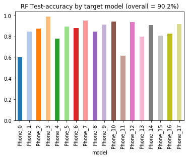

```python
class_score = Utilities.class_score(y_predict, y_test)
df_score = pd.DataFrame({"model":phone_labels, "score":class_score})
title = "RF Test-accuracy by target model (overall = {:.1%})".format(score)
df_score.plot.bar(x="model", y="score", title=title, legend=False, color=colors)
plt.show()
#plt.savefig("images/RF_class_score.png", bbox_inches="tight")
```

Looking back at the phone distribution, we see that Phone_3 was by far the most dominant one. It is therefore not surprising that it has the highest class accuracy, because that would optimize the overall accuracy. At the same time, we used the f1 score to minimize this impact. The other interesting peak would be Phone_8, which is the second most dominant in the distribution. However, in this graph it is pretty average.

Now, let's look at the features importance.

```
The 50 most important Features:
1. feature 323 (0.088775)
2. feature 181 (0.056573)
3. feature 175 (0.025695)
4. feature 176 (0.025266)
5. feature 214 (0.020854)
6. feature 215 (0.020738)
7. feature 265 (0.016347)
8. feature 191 (0.014132)
9. feature 212 (0.013954)
10. feature 190 (0.013895)
```

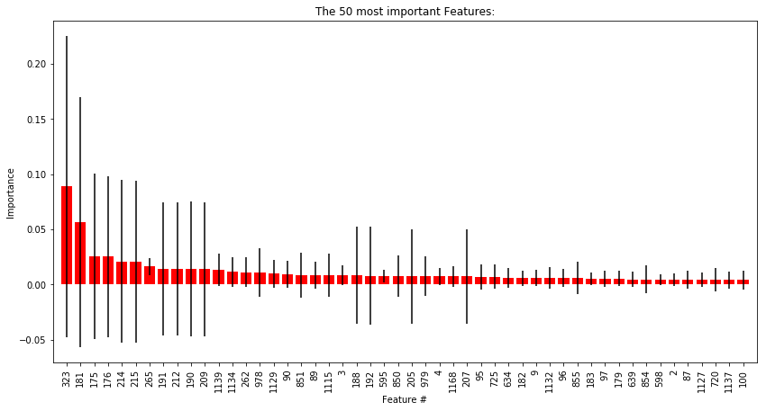

```python
#credit: inspired from scikit-learn's plot_forest_importances
n = 50
importances = best_RF.feature_importances_
std = np.std([tree.feature_importances_ for tree in best_RF.estimators_],
             axis=0)
indices = np.argsort(importances)[::-1]
indices = indices[0:n]

# Print the feature ranking
title = "The {} most important Features:".format(n)
print(title)

for f in range(min(n,10)):
    print("%d. feature %d (%f)" % (f + 1, indices[f], importances[indices[f]]))

# Plot the feature importances of the forest
plt.figure(figsize=(14,7))
plt.title(title)
plt.bar(range(n), importances[indices],
       color="r", yerr=std[indices], align="center")
plt.xticks(range(n), indices, rotation="vertical")
plt.xlim([-1, n])
plt.xlabel("Feature #")
plt.ylabel("Importance")
plt.show()
#plt.savefig("images/RF_importance.png",bbox_inches="tight")
```

In the plot above, the red bars are the feature importances of the forest, along with their inter-trees variability in black.

What's next? Here are a few improvements we could do: